# Исследование интернет-магазина "Стримчик"

#### Посмотрите на общее распределение игр по жанрам. Что можно сказать о самых прибыльных жанрах? Выделяются ли жанры с высокими и низкими продажами?

```python
genre_pivot_table = actual_data.pivot_table(index='genre', values='world_sales', aggfunc='sum').sort_values(by='world_sales',ascending=False)
genre_pivot_table
```

| genre | world_sales |
| --- | --- |
| Action | 199.36 |
| Shooter | 170.94 |
| Sports | 109.48 |
| Role-Playing | 101.44 |
| Misc | 37.55 |
| Fighting | 28.22 |
| Racing | 27.52 |
| Platform | 18.09 |
| Adventure | 17.55 |
| Simulation | 13.13 |
| Strategy | 3.96 |
| Puzzle | 2.21 |

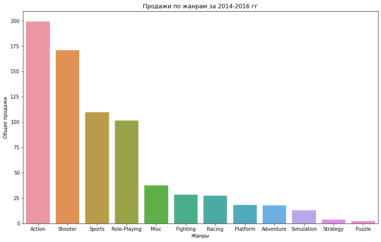

```python
plt.figure(figsize=(13, 8))
(sns.barplot(data = genre_pivot_table, x = genre_pivot_table.index, y = 'world_sales')
    .set(title = 'Продажи по жанрам за 2014-2016 гг', xlabel = 'Жанры', ylabel = 'Общие продажи'))

plt.show()
```

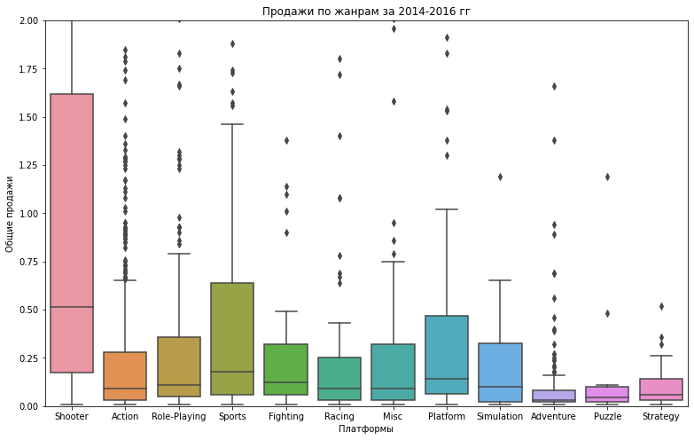

```python
plt.figure(figsize=(13, 8))
(sns.boxplot(data = actual_data, y = 'world_sales', x='genre')
    .set(title = 'Продажи по жанрам за 2014-2016 гг', xlabel = 'Платформы', ylabel = 'Общие продажи', ylim=(0, 2)))

plt.show()
```

**Вывод**

## Составьте портрет пользователя каждого региона

Определите для пользователя каждого региона (NA, EU, JP):

- Самые популярные платформы (топ-5). Опишите различия в долях продаж.
- Самые популярные жанры (топ-5). Поясните разницу.
- Влияет ли рейтинг ESRB на продажи в отдельном регионе?

```python
actual_data.info()
```

```
<class 'pandas.core.frame.DataFrame'>
Int64Index: 1689 entries, 31 to 16714
Data columns (total 12 columns):
 #   Column           Non-Null Count  Dtype
---  ------           --------------  -----
 0   name             1689 non-null   object
 1   platform         1689 non-null   object
 2   year_of_release  1689 non-null   int64
 3   genre            1689 non-null   object
 4   na_sales         1689 non-null   float64
 5   eu_sales         1689 non-null   float64
 6   jp_sales         1689 non-null   float64
 7   other_sales      1689 non-null   float64
 8   critic_score     718 non-null    float64
 9   user_score       888 non-null    float64
 10  rating           940 non-null    object
 11  world_sales      1689 non-null   float64
dtypes: float64(7), int64(1), object(4)
memory usage: 236.1+ KB
```

### Самые популярные платформы (топ-5)

#### Самые популярные платформы (топ-5) NA

```python
na_pivot_table = actual_data.pivot_table(index='platform',values='na_sales',aggfunc='sum').sort_values(by='na_sales',ascending=False)
na_pivot_table.head(5)
```

| platform | na_sales |
| --- | --- |
| PS4 | 98.61 |
| XOne | 81.27 |
| X360 | 28.30 |
| 3DS | 22.64 |
| PS3 | 22.05 |

#### Самые популярные платформы (топ-5) EU

```python
eu_pivot_table = actual_data.pivot_table(index='platform',values='eu_sales',aggfunc='sum').sort_values(by='eu_sales',ascending=False)
eu_pivot_table.head(5)
```

| platform | eu_sales |
| --- | --- |
| PS4 | 130.04 |
| XOne | 46.25 |
| PS3 | 25.54 |
| PC | 17.97 |
| 3DS | 16.12 |

#### Самые популярные платформы (топ-5) JP

```python
jp_pivot_table = actual_data.pivot_table(index='platform',values='jp_sales',aggfunc='sum').sort_values(by='jp_sales',ascending=False)
jp_pivot_table.head(5)
```

| platform | jp_sales |
| --- | --- |
| 3DS | 44.24 |
| PS4 | 15.02 |
| PSV | 14.54 |
| PS3 | 11.22 |
| WiiU | 7.31 |

**Рейтиинг платформ**

- Топ 5 в Северной Америке :PS4, XOne, X360, 3DS и PS3
- Топ 5 в Европе: PS4, XOne,PS3, PC и 3DS
- Топ 5 в Японии: 3DS, PS4, PSV, PS3 и WiiU

**Вывод:** Можно отметить сходство Северной Америки и Европы в том плане, что в обеих регионах на первом месте стоит платформа PS4, а второе место занимает XOne. Япония по сравнению с другими регионами своеобразна, здесь на первом месте стоит 3DS, второе место занимает PS4, и на третьем находится PSV.

### Самые популярные жанры (топ-5)

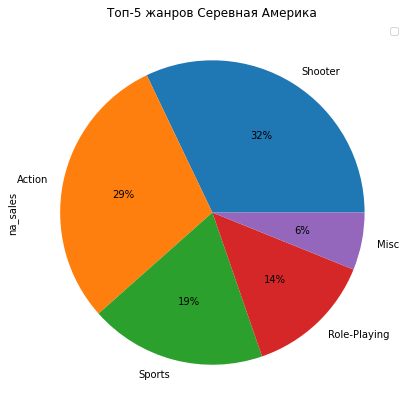

```python
na_genre_pivot_table = actual_data.pivot_table(index='genre',values='na_sales',aggfunc='sum').sort_values(by='na_sales',ascending=False)
na_genre_pivot_table.head(5).plot(kind='pie',figsize=(7,7),autopct='%1.0f%%',subplots=True)
plt.legend('')
plt.title('Топ-5 жанров Серевная Америка')
```

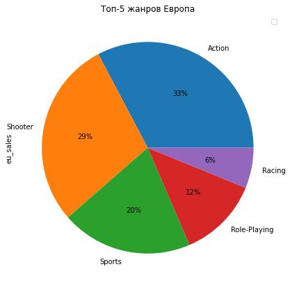

```python
eu_genre_pivot_table = actual_data.pivot_table(index='genre',values='eu_sales',aggfunc='sum').sort_values(by='eu_sales',ascending=False)
eu_genre_pivot_table.head(5).plot(kind='pie',figsize=(7,7),autopct='%1.0f%%',subplots=True)
plt.legend('')
plt.title('Топ-5 жанров Европа')
```

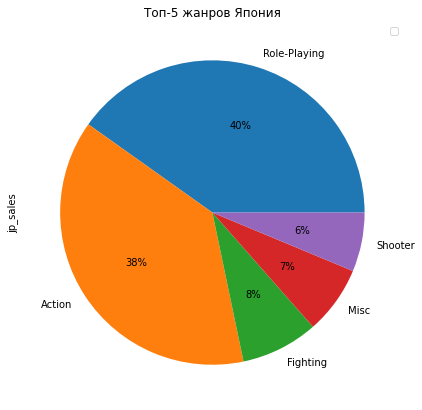

```python
jp_genre_pivot_table = actual_data.pivot_table(index='genre',values='jp_sales',aggfunc='sum').sort_values(by='jp_sales',ascending=False)
jp_genre_pivot_table.head(5).plot(kind='pie',figsize=(7,7),autopct='%1.0f%%',subplots=True)
plt.legend('')
plt.title('Топ-5 жанров Япония')
```

**Самые популярные жанры по регионам**

- Северная Америка: 1 - Shooter, 2 - Action, 3 - Sports
- Европа : 1 - Action, 2 - Shooter, 3 - Sports
- Япония: 1 - Playing, 2 - Action, 3 - Fighting
- Можно сделать вывод что в Северной Америке и Европе вкусы к играм примерно одинаковые.
- В Японии же в свою очередь игры координально отличаются

### Влияет ли рейтинг ESRB на продажи в отдельном регионе?

```python
ESRB = actual_data.pivot_table(index = 'rating', values = ['na_sales','eu_sales','jp_sales'], aggfunc = 'sum')
ESRB
```

| rating | eu_sales | jp_sales | na_sales |
| --- | --- | --- | --- |
| E | 58.06 | 8.94 | 50.74 |
| E10+ | 26.16 | 4.46 | 33.23 |
| M | 93.44 | 8.01 | 96.42 |
| T | 34.07 | 14.78 | 38.95 |

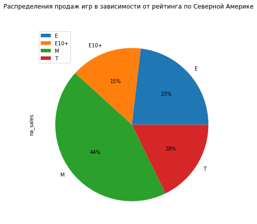

```python
ESRB_na = actual_data.pivot_table(index = 'rating', values = 'na_sales', aggfunc = 'sum').plot(kind='pie',subplots=True,autopct='%1.0f%%',figsize=(7,7),title='Распределения продаж игр в зависимости от рейтинга по Северной Америке')
```

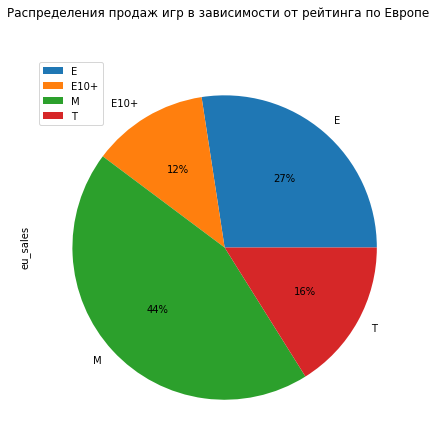

```python
ESRB_eu = actual_data.pivot_table(index = 'rating', values = 'eu_sales', aggfunc = 'sum').plot(kind='pie',subplots=True,autopct='%1.0f%%',figsize=(7,7),title='Распределения продаж игр в зависимости от рейтинга по Европе')
```

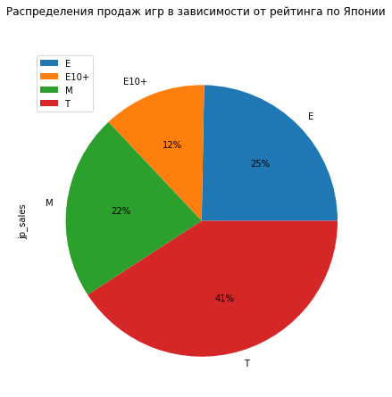

```python
ESRB_jp = actual_data.pivot_table(index = 'rating', values = 'jp_sales', aggfunc = 'sum').plot(kind='pie',subplots=True,autopct='%1.0f%%',figsize=(7,7),title='Распределения продаж игр в зависимости от рейтинга по Японии')
```

## Проверьте гипотезы

- Средние пользовательские рейтинги платформ Xbox One и PC одинаковые;
- Средние пользовательские рейтинги жанров Action (англ. «действие», экшен-игры) и Sports (англ. «спортивные соревнования») разные.

### Средние пользовательские рейтинги платформ Xbox One и PC одинаковые;

Сформулируем гипотезу

- H0 - Пользовательские рейтинги платформ Xbox One и PC одинаковые
- H1 - Пользовательские рейтинги платформ Xbox One и PC разные

```python
XOne = actual_data.query('platform == "XOne" & user_score > 0 ')['user_score']
PC = actual_data.query('platform == "PC" & user_score > 0')['user_score']
print('Средний пользовательский рейтинг платформы Xbox One:', XOne.mean().round(2))
print('Средний пользовательский рейтинг платформы Xbox One:', PC.mean().round(2))

alpha = 0.05
results = st.ttest_ind(XOne,PC)
print('p-значение:', results.pvalue)

if (results.pvalue < alpha):
    print("Отвергаем нулевую гипотезу")
else:
    print("Не получилось отвергнуть нулевую гипотезу")
```

```
Средний пользовательский рейтинг платформы Xbox One: 6.59
Средний пользовательский рейтинг платформы Xbox One: 6.3
p-значение: 0.10450507919348415
Не получилось отвергнуть нулевую гипотезу
```

**Вывод:** С большой долей вероятности средние пользовательские рейтинги платформ XOne и PC не имеют статистически значимых отличий

### Средние пользовательские рейтинги жанров Action (англ. «действие», экшен-игры) и Sports (англ. «спортивные соревнования») разные.

- H0 = Пользовательские рейтинги жанров Action и Sports равны
- H1 = Пользовательские рейтинги жанров Action и Sports разные

```python
Action = actual_data.query('genre == "Action" & user_score > 0 ')['user_score']
Sports = actual_data.query('genre == "Sports" & user_score > 0')['user_score']
print('Средний пользовательский рейтинг платформы Xbox One:', Action.mean().round(2))
print('Средний пользовательский рейтинг платформы Xbox One:', Sports.mean().round(2))

alpha = 0.05
results = st.ttest_ind(Action,Sports)
print('p-значение:', results.pvalue)

if (results.pvalue < alpha):
    print("Отвергаем нулевую гипотезу")
else:
    print("Не получилось отвергнуть нулевую гипотезу")
```

```
Средний пользовательский рейтинг платформы Xbox One: 6.76
Средний пользовательский рейтинг платформы Xbox One: 5.23
p-значение: 2.8711147985105864e-19
Отвергаем нулевую гипотезу
```

**Вывод:** Нулевая гипотеза отвергнута, с большой долей вероятности пользовательские рейтинги жанров Action и Sports имеют статистические различия

## Общий вывод

В ходе исследования данных были выполнены следующие действия

### Загружены данные и изучена общая информация интернет-магазинчика “Стримчик”

### Произведена подготовка данных:

- Заменены названия столбцов.
- Изменен тип данных.
- Исследованы пропуски.

### Добавлен новый столбец с суммарными продажами по всем регионам

### Проведен исследовательский анализ данных:

- Исследованы данные за разные периоды по годам
- данные по играм с 1980 по 2016
- До 1995 игр было слишком мало.
- Большо кол-во игр выпускалось с 2005 по 2011 года
- Максимальное кол-во игр пришлось на 2008 = 1427, 2009- 1426
- С 2011 года количество игр снизилось в среднем до 500-600
- Данные за все периоды важны, благодаря этому можно проследить динамику разработки игр.

### Исследованы данные о продажах по платформам

**Самая популярныая приставка на которую продано было максимальное кол-во игр это PS2.**

*По годам популярность распеделилась следующим образом:*

- PS2 -- 2001 - 2005
- X360 -- 2008 - 2011
- PS3 -- 2008 - 2011
- Wii -- 2006 - 2009
- DS -- 2005 - 2009
- PS -- 1997- 1999
- GBA -- 2001 - 2005

### Далее принято решение использовать только актуальные данные за 2014-2016 года

### Какие платформы лидируют по продажам

- Если анализировать данные за последние 3 года то картина по продаже игр координально изменилась. Больше всего продаж у PS4 и XboxOne. Можно сделать вывод что данные 2 приставки для нас более перспективны.

### Проведено исследование влияния на продажи отзывов пользователей и критиков втнутри одной плотформы

- Для платформы PS4 важным критерием является оценка критиков, на графика видна прямая корреляция между прибылью и рейтингом критиков.

*Так же были проведены исследования еще по 3 платформам*

- По платформам PS3 и XOne ситуация аналогичная с PS4, количество продаж напрямую зависит от оценки критиков
- 3DS ситуация другая, продажи так же зависят и от оценки игроков

### Проведен анализ самых популярных платформ

**Рейтиинг платформ**

- Топ 5 в Северной Америке :PS4, XOne, X360, 3DS и PS3
- Топ 5 в Европе: PS4, XOne,PS3, PC и 3DS
- Топ 5 в Японии: 3DS, PS4, PSV, PS3 и WiiU

**Вывод:** Можно отметить сходство Северной Америки и Европы в том плане, что в обеих регионах на первом месте стоит платформа PS4, а второе место занимает XOne. Япония по сравнению с другими регионами своеобразна, здесь на первом месте стоит 3DS, второе место занимает PS4, и на третьем находится PSV.

### Проведен анализ самых популярных жанров игр

**Самые популярные жанры по регионам**

- Северная Америка: 1 - Shooter, 2 - Action, 3 - Sports
- Европа : 1 - Action, 2 - Shooter, 3 - Sports
- Япония: 1 - Playing, 2 - Action, 3 - Fighting

**Можно сделать вывод что в Северной Америке и Европе вкусы к играм примерно одинаковые.В Японии же в свою очередь игры координально отличаются**

### Проверены гипотезы:

- Средние пользовательские рейтинги платформ Xbox One и PC одинаковые;

- Средние пользовательские рейтинги жанров Action (англ. «действие», экшен-игры) и Sports (англ. «спортивные соревнования») разные.

**Вывод:** Нулевая гипотеза отвергнута, следовательно пользовательские рейтинги жанров Action и Sports разные

## Рекомендации по развитию интернет-магазина "Стримчик"

- Делать ставку на современные платформы. Покупать вышедшие и новые игры на PS4, XOne и 3DS.
- Делать ставку на игры в следующих жанрах экшен, шутеры, спортивные и ролевые игры.
- Больше всего игр должно быть с расчетом на игроков в возрасте от 17 лет